# Sorting

## 1. Bubble Sort

adalah pertukaran dengan waktu yang lama, pengecekan akan terus dilakukan jika terjadi pertukaran maka akan ditukar jika tidak pengecekan akan tetep terjadi, proses ini akan berulang sampe pertukaran akhir selesai. Bubble Sort adalah pengurutan yang paling sederhana.

Cara mengurutkan datanya adalah:

1. data dibaca mulai dari yang paling kiri dari indeks 0 di suatu list data.
2. lakukan perbandingan besar kecilnya data
3. pindahkan satu posisi
4. lakukan perbandingan seperti langkah ke-2 dan pindah satu posisi kembali seperti langkah ke-3. Lakukan terus menerus sampai indeks data terakhir.
5. Setelah langkah ke-4 dilakukan, maka data yang berada di posisi paling kanan (indeks ke-N) adalah data terbesar .
6. ulangi serta melakukan dan lakukan pengecekan

```python
#menambahkan swap dan juga memangkas hanya 4 iterasi
def bubbleSort(listData):
    print('Data yang akan diurutkan : ', listData)
    count=0
    for outIter in range(len(listData)-1,-1,-1):
        if count == 4:
            break
        print('outIter=',outIter)
        count=count+1
        print ('Iterasi ke-', count,':')
        for i in range(outIter):
            if listData[i]>listData[i+1]:
                temp=listData[i]
                listData[i]=listData[i+1]
                listData[i+1]=temp
                swap =+1
                #listData[i],listData[i+1]=listData[i+1],listData[i]
            print(outIter,'=',listData)
        print('Data urut-',listData)
        print('jumlah swap= ', swap)
a = [90,112,5,1,11,20,17,2]
bubbleSort(a)
b=[15,7,8,9,0]
print('---')
bubbleSort(b)
```

```
Data yang akan diurutkan :  [90, 112, 5, 1, 11, 20, 17, 2]
outIter= 7
Iterasi ke- 1 :
7 = [90, 112, 5, 1, 11, 20, 17, 2]
7 = [90, 5, 112, 1, 11, 20, 17, 2]
7 = [90, 5, 1, 112, 11, 20, 17, 2]
7 = [90, 5, 1, 11, 112, 20, 17, 2]
7 = [90, 5, 1, 11, 20, 112, 17, 2]
7 = [90, 5, 1, 11, 20, 17, 112, 2]
7 = [90, 5, 1, 11, 20, 17, 2, 112]
Data urut- [90, 5, 1, 11, 20, 17, 2, 112]
jumlah swap=  1
outIter= 6
Iterasi ke- 2 :
6 = [5, 90, 1, 11, 20, 17, 2, 112]
6 = [5, 1, 90, 11, 20, 17, 2, 112]
6 = [5, 1, 11, 90, 20, 17, 2, 112]
6 = [5, 1, 11, 20, 90, 17, 2, 112]
6 = [5, 1, 11, 20, 17, 90, 2, 112]
6 = [5, 1, 11, 20, 17, 2, 90, 112]
Data urut- [5, 1, 11, 20, 17, 2, 90, 112]
jumlah swap=  1
outIter= 5
Iterasi ke- 3 :
5 = [1, 5, 11, 20, 17, 2, 90, 112]
5 = [1, 5, 11, 20, 17, 2, 90, 112]
5 = [1, 5, 11, 20, 17, 2, 90, 112]
5 = [1, 5, 11, 17, 20, 2, 90, 112]
5 = [1, 5, 11, 17, 2, 20, 90, 112]
Data urut- [1, 5, 11, 17, 2, 20, 90, 112]
jumlah swap=  1
outIter= 4
Iterasi ke- 4 :
4 = [1, 5, 11, 17, 2, 20, 90, 112]
4 = [1, 5, 11, 17, 2, 20, 90, 112]
4 = [1, 5, 11, 17, 2, 20, 90, 112]
4 = [1, 5, 11, 2, 17, 20, 90, 112]
Data urut- [1, 5, 11, 2, 17, 20, 90, 112]
jumlah swap=  1
---
```

[output cut: 12 more lines]

```
3 = [7, 8, 9, 0, 15]
3 = [7, 8, 0, 9, 15]
Data urut- [7, 8, 0, 9, 15]
jumlah swap=  1
outIter= 2
Iterasi ke- 3 :
2 = [7, 8, 0, 9, 15]
2 = [7, 0, 8, 9, 15]
Data urut- [7, 0, 8, 9, 15]
jumlah swap=  1
outIter= 1
Iterasi ke- 4 :
1 = [0, 7, 8, 9, 15]
Data urut- [0, 7, 8, 9, 15]
jumlah swap=  1
```

```python
#descanding mulai dari awal
def bubbleSort(listData):
    print('Data yang akan diurutkan : ', listData)
    count=0
    for outIter in range(len(listData)-1,-1,-1):
        if count == 4:
            break
        print('outIter=',outIter)
        count=count+1
        print ('Iterasi ke-', count,':')
        for i in range(outIter):
            if listData[i]<listData[i+1]:
                temp=listData[i]
                listData[i]=listData[i+1]
                listData[i+1]=temp
                swap =+1

            print(outIter,'=',listData)
        print('Data urut-',listData)
        print('jumlah swap= ', swap)
a = [90,112,5,1,11,20,17,2]
bubbleSort(a)
b=[15,7,8,9,0]
print('---')
bubbleSort(b)
```

```
Data yang akan diurutkan :  [90, 112, 5, 1, 11, 20, 17, 2]
outIter= 7
Iterasi ke- 1 :
7 = [112, 90, 5, 1, 11, 20, 17, 2]
7 = [112, 90, 5, 1, 11, 20, 17, 2]
7 = [112, 90, 5, 1, 11, 20, 17, 2]
7 = [112, 90, 5, 11, 1, 20, 17, 2]
7 = [112, 90, 5, 11, 20, 1, 17, 2]
7 = [112, 90, 5, 11, 20, 17, 1, 2]
7 = [112, 90, 5, 11, 20, 17, 2, 1]
Data urut- [112, 90, 5, 11, 20, 17, 2, 1]
jumlah swap=  1
outIter= 6
Iterasi ke- 2 :
6 = [112, 90, 5, 11, 20, 17, 2, 1]
6 = [112, 90, 5, 11, 20, 17, 2, 1]
6 = [112, 90, 11, 5, 20, 17, 2, 1]
6 = [112, 90, 11, 20, 5, 17, 2, 1]
6 = [112, 90, 11, 20, 17, 5, 2, 1]
6 = [112, 90, 11, 20, 17, 5, 2, 1]
Data urut- [112, 90, 11, 20, 17, 5, 2, 1]
jumlah swap=  1
outIter= 5
Iterasi ke- 3 :
5 = [112, 90, 11, 20, 17, 5, 2, 1]
5 = [112, 90, 11, 20, 17, 5, 2, 1]
5 = [112, 90, 20, 11, 17, 5, 2, 1]
5 = [112, 90, 20, 17, 11, 5, 2, 1]
5 = [112, 90, 20, 17, 11, 5, 2, 1]
Data urut- [112, 90, 20, 17, 11, 5, 2, 1]
jumlah swap=  1
outIter= 4
Iterasi ke- 4 :
4 = [112, 90, 20, 17, 11, 5, 2, 1]
4 = [112, 90, 20, 17, 11, 5, 2, 1]
4 = [112, 90, 20, 17, 11, 5, 2, 1]
4 = [112, 90, 20, 17, 11, 5, 2, 1]
Data urut- [112, 90, 20, 17, 11, 5, 2, 1]
jumlah swap=  1
---
```

[output cut: 12 more lines]

```
3 = [15, 9, 8, 7, 0]
3 = [15, 9, 8, 7, 0]
Data urut- [15, 9, 8, 7, 0]
jumlah swap=  1
outIter= 2
Iterasi ke- 3 :
2 = [15, 9, 8, 7, 0]
2 = [15, 9, 8, 7, 0]
Data urut- [15, 9, 8, 7, 0]
jumlah swap=  1
outIter= 1
Iterasi ke- 4 :
1 = [15, 9, 8, 7, 0]
Data urut- [15, 9, 8, 7, 0]
jumlah swap=  1
```

```python
#descanding mulai dari akhir
def bubbleSort(listData):
    print('Data yang akan diurutkan : ', listData)
    count = 0
    swap = 0

    for outIter in range(len(listData)-1, -1, -1):
        if count == 4:
            break

        print('outIter=', outIter)
        count += 1
        print('Iterasi ke-', count, ':')

        for i in range(outIter):
            if listData[i] < listData[i+1]:
                temp = listData[i]
                listData[i] = listData[i+1]
                listData[i+1] = temp
                swap += 1

            print(outIter, '=', listData)

        print('Data urut-', listData)

    print('Jumlah swap =', swap)
a = [90,112,5,1,11,20,17,2]
bubbleSort(a)
b=[15,7,8,9,0]
print('---')
bubbleSort(b)
```

```
Data yang akan diurutkan :  [90, 112, 5, 1, 11, 20, 17, 2]
outIter= 7
Iterasi ke- 1 :
7 = [112, 90, 5, 1, 11, 20, 17, 2]
7 = [112, 90, 5, 1, 11, 20, 17, 2]
7 = [112, 90, 5, 1, 11, 20, 17, 2]
7 = [112, 90, 5, 11, 1, 20, 17, 2]
7 = [112, 90, 5, 11, 20, 1, 17, 2]
7 = [112, 90, 5, 11, 20, 17, 1, 2]
7 = [112, 90, 5, 11, 20, 17, 2, 1]
Data urut- [112, 90, 5, 11, 20, 17, 2, 1]
outIter= 6
Iterasi ke- 2 :
6 = [112, 90, 5, 11, 20, 17, 2, 1]
6 = [112, 90, 5, 11, 20, 17, 2, 1]
6 = [112, 90, 11, 5, 20, 17, 2, 1]
6 = [112, 90, 11, 20, 5, 17, 2, 1]
6 = [112, 90, 11, 20, 17, 5, 2, 1]
6 = [112, 90, 11, 20, 17, 5, 2, 1]
Data urut- [112, 90, 11, 20, 17, 5, 2, 1]
outIter= 5
Iterasi ke- 3 :
5 = [112, 90, 11, 20, 17, 5, 2, 1]
5 = [112, 90, 11, 20, 17, 5, 2, 1]
5 = [112, 90, 20, 11, 17, 5, 2, 1]
5 = [112, 90, 20, 17, 11, 5, 2, 1]
5 = [112, 90, 20, 17, 11, 5, 2, 1]
Data urut- [112, 90, 20, 17, 11, 5, 2, 1]
outIter= 4
Iterasi ke- 4 :
4 = [112, 90, 20, 17, 11, 5, 2, 1]
4 = [112, 90, 20, 17, 11, 5, 2, 1]
4 = [112, 90, 20, 17, 11, 5, 2, 1]
4 = [112, 90, 20, 17, 11, 5, 2, 1]
Data urut- [112, 90, 20, 17, 11, 5, 2, 1]
Jumlah swap = 10
---
Data yang akan diurutkan :  [15, 7, 8, 9, 0]
outIter= 4
Iterasi ke- 1 :
4 = [15, 7, 8, 9, 0]
4 = [15, 8, 7, 9, 0]
4 = [15, 8, 9, 7, 0]
4 = [15, 8, 9, 7, 0]
Data urut- [15, 8, 9, 7, 0]
outIter= 3
Iterasi ke- 2 :
3 = [15, 8, 9, 7, 0]
3 = [15, 9, 8, 7, 0]
3 = [15, 9, 8, 7, 0]
Data urut- [15, 9, 8, 7, 0]
outIter= 2
Iterasi ke- 3 :
2 = [15, 9, 8, 7, 0]
2 = [15, 9, 8, 7, 0]
Data urut- [15, 9, 8, 7, 0]
outIter= 1
Iterasi ke- 4 :
1 = [15, 9, 8, 7, 0]
Data urut- [15, 9, 8, 7, 0]
Jumlah swap = 3
```

## 2. Selection Sort

Mencari yang terkecil dan akan melakukan perbandingan dengan waktu yang lebih cepat pada saat proses pertukaran, bedanya dengan bubble sort dia membandingkan lagsung ditukar, kalo selection sort dibandingkan baru ditukar lalu posisinya di taruh di posisi awal. perbedaan dengan selection sort dan insert sort : selection sort itu mencari nilai index yang terkecil, insert sort meng insert posisi yang diinginkan

```python
def selectionSort(listData):
    print('Algoritma Selection Sort konvensional')
    print('Data Awal=',listData)
    for outIter in range(len(listData)-1):
        minIndex=outIter
        for i in range(outIter+1,len(listData)):
            if listData[i]<listData[minIndex]:
                minIndex=i
        temp=listData[outIter]
        listData[outIter]=listData[minIndex]
        listData[minIndex]=temp
        print('Iterasi ke-',outIter+1,':',listData)
    print('Data Urut=',listData)
a = [19,8,5,2,0,1]
selectionSort(a)
```

```
Algoritma Selection Sort konvensional
Data Awal= [19, 8, 5, 2, 0, 1]
Iterasi ke- 1 : [0, 8, 5, 2, 19, 1]
Iterasi ke- 2 : [0, 1, 5, 2, 19, 8]
Iterasi ke- 3 : [0, 1, 2, 5, 19, 8]
Iterasi ke- 4 : [0, 1, 2, 5, 19, 8]
Iterasi ke- 5 : [0, 1, 2, 5, 8, 19]
Data Urut= [0, 1, 2, 5, 8, 19]
```

```python
lst = [4, 7, 1, 0]

for i in range(1, len(lst)):
    nilaiawal = lst[i]
    hole = i

    while hole > 0 and lst[hole - 1] > nilaiawal:
        lst[hole] = lst[hole - 1]
        hole = hole - 1

    lst[hole] = nilaiawal

print(lst)
```

```
[0, 1, 4, 7]
```

```python
def QuickSortAwal(A):
    QuickSort(A, 0, len(A) - 1)

def QuickSort(A, start, end):
    if start < end:
        pIndex = Partition(A, start, end)
        QuickSort(A, start, pIndex - 1)
        QuickSort(A, pIndex + 1, end)

def Partition(A, start, end):
    pivot = A[end]
    pIndex = start

    for i in range(start, end):
        if A[i] <= pivot:
            A[i], A[pIndex] = A[pIndex], A[i]
            pIndex = pIndex + 1

    A[pIndex], A[end] = A[end], A[pIndex]
    return pIndex

A = [100, 6, 500, 4, 56, 2, 1, 0]

QuickSortAwal(A)

print(A)
```

```
[0, 1, 2, 4, 6, 56, 100, 500]
```

## 3. Insert Sort

Pada algoritma insertion sort, diasumsikan bahwa sebagian data sudah dalam keadaan terurut (pada posisi sebelah kiri dari data list), sehingga data berikutnya akan dibandingkan dengan data yang sudah dalam keadaan terurut ini, dan disisipkan (insertion) pada bagian data yang sudah terurut tersebut. Dengan konsep seperti ini, posisi sebelah kiri dari list data (sebelum ada data baru yang akan disisipkan), selalu dalam keadaan terurut.

Berikut algoritma Insertion Sort :

```python
def insertion_sort(arr):
    # Start from the second element (index 1)
    for i in range(1, len(arr)):
        key = arr[i]
        j = i - 1

        # Shift elements of arr[0..i-1] that are greater than key
        # to one position ahead of their current position
        while j >= 0 and arr[j] > key:
            arr[j + 1] = arr[j]
            j -= 1

        # Insert the key into its correct position
        arr[j + 1] = key
    return arr

# Example usage:
my_list = [12, 11, 13, 5, 6]
print(f"Original: {my_list}")
print(f"Sorted:   {insertion_sort(my_list)}")
```

```
Original: [12, 11, 13, 5, 6]
Sorted:   [5, 6, 11, 12, 13]
```

## 4. Quick Sort

Algoritma sorting berikutnya adalah Quick Sort. Tahapan pengurutan algoritma ini sama halnya dengan algoritma Merge Sort, yaitu proses divide dan combine. Hanya saja Jika pada algoritma merge sort, proses divide, dilakukan dengan cara membagi data menjadi dua buah bagian, dan proses pengurutan terjadi pada proses merging/combine. Maka pada algoritma Quick Sort, terdapat perbedaan. Ada dua tahap algoritmanya yaitu divide dan combine

Berikut adalah penjelasan tentang 2 tahap tersebut:

### 1. Divide

Berbeda dengan algoritma merge sort yang membagi data menjadi dua bagian, tanpa syarat apapun, maka pada algoritma quick sort ini, pembagian data menjadi dua buah bagian, harus memenuhi ketentuan bahwa, data yang berada di bagian sebelah kiri (bagian data pertama), haruslah data-data yang memiliki nilai lebih kecil dari nilai pivot (tidak harus urut). Sedangkan, data-data yang berada disebelah kanan (bagian data kedua), adalah data-data yang memiliki nilai lebih besar dari nilai pivot, seperti yang terlihat pada Gambar 1.

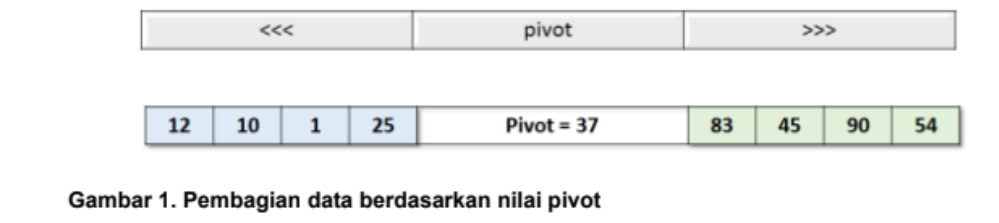

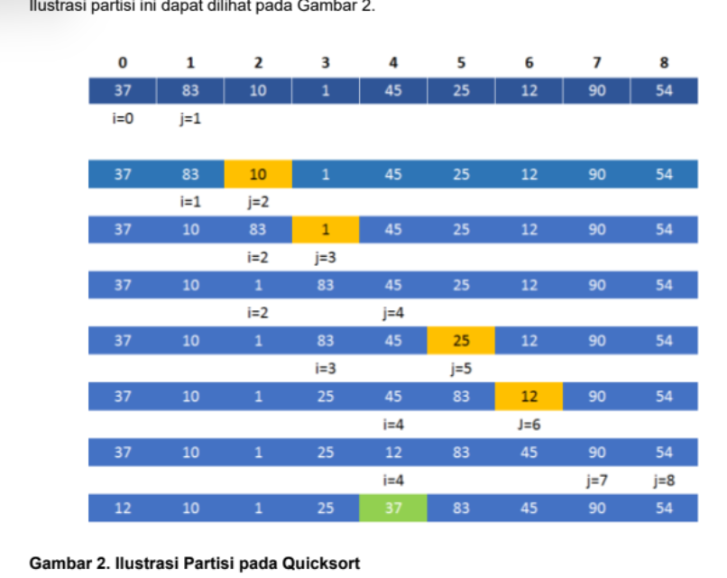

### 2. Combine

Tahap kedua pada algoritma quicsort adalah tahapan combine. Pada tahapan ini, hanya memerintahkan partisi yang berulang kali. Data yang sudah dipartisi, akan terdiri dari dua bagian data, yaitu bagian pertama dan kedua. Bagian pertama dilakukan partisi lagi, menjadi dua buah bagian, begitu juga bagian kedua, begitu seterusnya, sampai tidak ada data lagi yang akan dipartisi. Sehingga hasil akhir adalah, data akan terurut. Pada contoh Gambar 2 tersebut, nilai pivot berada pada indeks ke-4. Nilai pivot di akhir proses partisi, menempati indeks yang sebenarnya, ketika data tersebut dalam keadaan terurut. Sehingga proses partisi akan dilakukan pada data-data sebelum nilai pivot, dan data setelah nilai pivot. Proses combine yang dilakukan dengan cara memerintahkan partisi berulang, seperti yang terlihat pada Gambar 3.

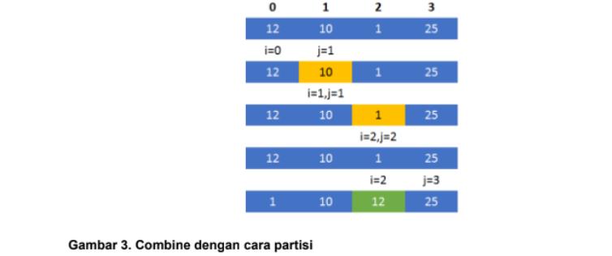

Berikut adalah implementasi code nya:

```python
def quicksort(arr):
    if len(arr) <= 1:
        return arr

    pivot = arr[len(arr) // 2]

    # Divide
    kiri = [x for x in arr if x < pivot]
    tengah = [x for x in arr if x == pivot]
    kanan = [x for x in arr if x > pivot]

    # Combine
    return quicksort(kiri) + tengah + quicksort(kanan)


# Contoh penggunaan
data = [8, 3, 1, 7, 0, 10, 2]

print("Data sebelum sorting:", data)

hasil = quicksort(data)

print("Data setelah sorting:", hasil)
```

```
Data sebelum sorting: [8, 3, 1, 7, 0, 10, 2]
Data setelah sorting: [0, 1, 2, 3, 7, 8, 10]
```

## 5. Merge Sort

Merge Sort merupakan algoritma pengurutan dengan konsep rekursif, yang terdiri dari dua tahapan utama, yaitu

### 1. Splitting atau proses divide

Proses Splitting atau Divide adalah proses yang membagi list data menjadi dua buah bagian. Proses splitting data list ini dilakukan secara terus menerus, sampai hanya tersisa satu elemen saja didalam list. Top-Down Process

### 2. Merging

Proses Merge ini menggabungkan data-data yang sudah terbagi pada Tahap pertama (divide/split). Proses merge ini juga melibatkan proses membandingkan data antara list yang akan digabung. Sehingga, setelah proses merge, data pada list akan terurut. Proses ini akan dilakukan terus menerus, sehingga tidak ada lagi list yang akan digabungkan. Tahapan merge ini adalah Bottom - up process

Berikut adalah implementasi code nya:

```python
def merge_sort(arr):
    if len(arr) <= 1:
        return arr

    tengah = len(arr) // 2

    # Divide
    kiri = merge_sort(arr[:tengah])
    kanan = merge_sort(arr[tengah:])

    # Merging
    hasil = []
    i = j = 0

    while i < len(kiri) and j < len(kanan):
        if kiri[i] < kanan[j]:
            hasil.append(kiri[i])
            i += 1
        else:
            hasil.append(kanan[j])
            j += 1

    hasil.extend(kiri[i:])
    hasil.extend(kanan[j:])

    return hasil


# Contoh penggunaan
data = [8, 3, 1, 7, 0, 10, 2]

print("Data sebelum sorting:", data)

hasil = merge_sort(data)

print("Data setelah sorting:", hasil)
```

```
Data sebelum sorting: [8, 3, 1, 7, 0, 10, 2]
Data setelah sorting: [0, 1, 2, 3, 7, 8, 10]
```

## 6. Shell Sort

Shell Sort adalah algoritma sorting yang merupakan pengembangan dari Insertion Sort. Metode ini bekerja dengan membandingkan elemen yang berjauhan terlebih dahulu menggunakan nilai tertentu yang disebut gap.

```python
def shell_sort(arr):
    n = len(arr)

    # Menentukan gap awal
    gap = n // 2

    # Perulangan selama gap lebih dari 0
    while gap > 0:

        # Perulangan untuk membandingkan elemen
        for i in range(gap, n):

            temp = arr[i]
            j = i

            # Sorting berdasarkan gap
            while j >= gap and arr[j - gap] > temp:
                arr[j] = arr[j - gap]
                j -= gap

            arr[j] = temp

        # Gap diperkecil
        gap //= 2

    return arr


# Contoh penggunaan
data = [12, 34, 54, 2, 3]

print("Data sebelum sorting:", data)

hasil = shell_sort(data)

print("Data setelah sorting:", hasil)
```

```
Data sebelum sorting: [12, 34, 54, 2, 3]
Data setelah sorting: [2, 3, 12, 34, 54]
```